# Designing a Machine Learning Algorithm: A Step-By-Step Guide

Normalize the training and test data

```python
scaler = StandardScaler()
X_train_scaled = scaler.fit_transform(X_train)
X_test_scaled = scaler.fit_transform(X_test)
```

Perform k-folds cross-validation for KNN, DecisionTree, LogisticRegression, and RandomForest models

```python
from sklearn.tree import DecisionTreeClassifier as dtc
from sklearn.neighbors import KNeighborsClassifier as kn
from sklearn.linear_model import LogisticRegression as lr
from sklearn.ensemble import RandomForestClassifier as rfc

models = {
    "KNN": kn(),
    "DecisionTree": dtc(),
    "LogisticRegression": lr(),
    "RandomForest": rfc()
         }

k_folds = 5
skf = StratifiedKFold(n_splits=k_folds, shuffle=True, random_state=seed)

for model_name, model in models.items():
    np.random.seed(seed)
    scores = cross_val_score(model, X_train_scaled, y=y_train, cv=k_folds)
    print(model_name, ": ","Mean:", scores.mean(), " sd:", scores.std())
```

```
KNN :  Mean: 0.9233022455992197  sd: 0.0007129890469646576
DecisionTree :  Mean: 0.9313374243154364  sd: 0.0005165068770763361
LogisticRegression :  Mean: 0.919602198989818  sd: 0.00010929257610058818
RandomForest :  Mean: 0.9370991899821781  sd: 0.00032140902090791454
```

Train each model and show their accuracies and classification reports

```python
for model_name, model in models.items():
    np.random.seed(seed)
    model.fit(X_train_scaled, y_train)
    y_pred = model.predict(X_test_scaled)
    accuracy = accuracy_score(y_test, y_pred)
    print(f"Accuracy of {model_name}: {accuracy:.2f}")
    print(classification_report(y_test, y_pred))
    print()
```

```
Accuracy of KNN: 0.93
              precision    recall  f1-score   support

       False       0.95      0.97      0.96    100076
        True       0.54      0.36      0.43      8572

    accuracy                           0.93    108648
   macro avg       0.74      0.67      0.70    108648
weighted avg       0.91      0.93      0.92    108648


Accuracy of DecisionTree: 0.94
              precision    recall  f1-score   support

       False       0.96      0.97      0.97    100076
        True       0.62      0.51      0.56      8572

    accuracy                           0.94    108648
   macro avg       0.79      0.74      0.76    108648
weighted avg       0.93      0.94      0.93    108648


Accuracy of LogisticRegression: 0.92
              precision    recall  f1-score   support

       False       0.92      1.00      0.96    100076
        True       0.26      0.00      0.01      8572

    accuracy                           0.92    108648
   macro avg       0.59      0.50      0.48    108648
weighted avg       0.87      0.92      0.88    108648


Accuracy of RandomForest: 0.94
              precision    recall  f1-score   support

       False       0.96      0.98      0.97    100076
        True       0.66      0.52      0.58      8572

    accuracy                           0.94    108648
   macro avg       0.81      0.75      0.78    108648
weighted avg       0.94      0.94      0.94    108648
```

In this section we will train and evaluate a Random Forest Classifier on our scaled training data. The Random Forest algorithm is an ensemble learning method primarily used for classification and regression tasks that builds multiple decision trees and merges their predictions to improve accuracy and control overfitting.

```python
# Import the necessary libraries for Random Forest Classifier and evaluation metrics
from sklearn.ensemble import RandomForestClassifier # For building our Random Forest model
from sklearn.metrics import classification_report, confusion_matrix, accuracy_score # For our evaluation metrics
from sklearn.metrics import ConfusionMatrixDisplay # For visualizing the confusion matrix

# Initialize a Random Forest Classifier
rf_model = RandomForestClassifier(n_estimators=50, random_state=44)

# Train the Random Forest model using the training data
rf_model.fit(X_train_scaled, y_train)

# Make predictions using the trained model on the test data
y_pred = rf_model.predict(X_test_scaled)

# Evaluate the model using accuracy, classification report, and confusion matrix
accuracy = accuracy_score(y_test, y_pred)
classification_rep = classification_report(y_test, y_pred)
conf_matrix = confusion_matrix(y_test, y_pred)

print(f"Accuracy: {accuracy:.2f}")
print(classification_rep)
```

```
Accuracy: 0.94
              precision    recall  f1-score   support

       False       0.96      0.98      0.97    100076
        True       0.66      0.53      0.59      8572

    accuracy                           0.94    108648
   macro avg       0.81      0.75      0.78    108648
weighted avg       0.94      0.94      0.94    108648
```

The Random Forest Classifier achieved an overall accuracy of 94% which lets us know that the model correctly predicted the class for most of the test samples.

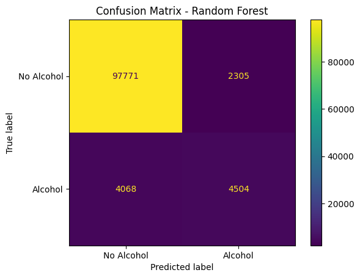

```python
disp = ConfusionMatrixDisplay(confusion_matrix=conf_matrix, display_labels=['No Alcohol', 'Alcohol'])
disp.plot()
plt.title("Confusion Matrix - Random Forest")
plt.show()
```

From this confusion matrix above we can see that our model is great at correctly identifying cases of No Alcohol but struggles to identify Alcohol cases. This could lead to underestimating cases of Alcohol use. The bias in the model may have to do with the significant number of No Alcohol cases vs Alcohol cases.

While Random Forests are a collection of multiple decision trees, visualizing one of the trees can provide us with some insight insights into how decisions are made in our model.

In the following code, we will extract and visualize one of the decision trees from our Random Tree Classifier.

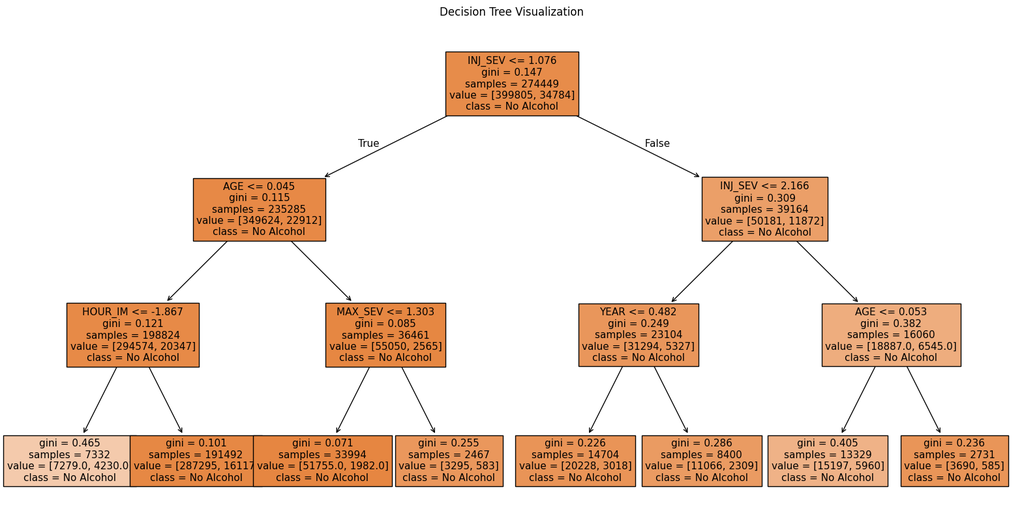

```python
from sklearn.tree import plot_tree
import matplotlib.pyplot as plt

# Train a limited-depth Random Forest
limited_tree = RandomForestClassifier(random_state=42, n_estimators=1, max_depth=3)
limited_tree.fit(X_train_scaled, y_train)

# Extract the decision tree from the Random Forest
tree = limited_tree.estimators_[0]

# Plot the decision tree
plt.figure(figsize=(20, 10))
plot_tree(
    tree,
    feature_names=X.columns,  # Feature names
    class_names=['No Alcohol', 'Alcohol'],  # Class labels
    filled=True,
    fontsize=11
)
plt.title("Decision Tree Visualization")
plt.show()
```

Overall the tree tells us that features like injury severity, age, and time related variables are important in classifying alcohol involvement in accidents.

# Conclusion

In conclusion, based on all of these different tests we can provide estimates on the different scenarios and reasonings based vehicluar accidents. As stated in our introduction, we wanted to use this dataset because as drivers, we are able to relate and create predictions when it comes to accidents in vehicles. It is very important to be able to see the correlation between the accidents with alcohol and without, amongst other characteristics.

An uninformed reader would be able to understand the data as we are able to help them make their own informed opinion. We give detailed information, several graphs, and utilized machine learning to further show correlation. A user should be able to use these and see the trends within the data.

An informed reader would feel like their prior judgement is validated. However they would learn more about how accidents can also be reflected with other variables such as age and time of day.

In an ever evolving world in which we are able to drive to different states and sometimes different countries, it is important to remain safe on the roads. With this data, we know the trends that occur within accidents and can see correlations to make safer choices within our lives.